# Tibble Join Demonstration

October 18, 2021

# Demonstration with `gapminder`

Load necessary packages

```r
library(tidyverse)
library(gapminder)
library(gsheet) # make sure to install this package if you don't have it
```

Get an overview of `gapminder` data

```r
glimpse(gapminder)
```

```
## Rows: 1,704
## Columns: 6
## $ country   <fct> "Afghanistan", "Afghanistan", "Afghanistan", "Afghanistan", ~
## $ continent <fct> Asia, Asia, Asia, Asia, Asia, Asia, Asia, Asia, Asia, Asia, ~
## $ year      <int> 1952, 1957, 1962, 1967, 1972, 1977, 1982, 1987, 1992, 1997, ~
## $ lifeExp   <dbl> 28.801, 30.332, 31.997, 34.020, 36.088, 38.438, 39.854, 40.8~
## $ pop       <int> 8425333, 9240934, 10267083, 11537966, 13079460, 14880372, 12~
## $ gdpPercap <dbl> 779.4453, 820.8530, 853.1007, 836.1971, 739.9811, 786.1134, ~
```

## Part 1

Obtain additional information on countries from other open data sources

```r
country_data <- read.csv(file = "https://raw.githubusercontent.com/open-numbers/ddf--gapminder--geo_entity_domain/master/ddf--entities--geo--country.csv")
glimpse(country_data)
```

```
## Rows: 273
## Columns: 33
## $ country                <chr> "abkh", "afg", "akr_a_dhe", "ala", "alb", "dza"~
## $ gwid                   <chr> "i0", "i1", "i2", "i258", "i3", "i4", "i5", "i6~
## $ name                   <chr> "Abkhazia", "Afghanistan", "Akrotiri and Dhekel~
## $ world_6region          <chr> "europe_central_asia", "south_asia", "europe_ce~
## $ income_groups          <chr> "", "low_income", "", "", "upper_middle_income"~
## $ landlocked             <chr> "", "landlocked", "coastline", "coastline", "co~
## $ g77_and_oecd_countries <chr> "others", "g77", "others", "others", "others", ~
## $ main_religion_2008     <chr> "", "muslim", "", "", "muslim", "muslim", "chri~
## $ gapminder_list         <chr> "Abkhazia", "Afghanistan", "Akrotiri and Dhekel~
## $ alternative_1          <chr> "", "Islamic Republic of Afghanistan", "", "â\2~
## $ alternative_2          <chr> "", "", "", "", "", "", "", "", "", "", "", "",~
## $ alternative_3          <chr> "", "", "", "", "", "", "", "", "", "", "", "",~
## $ alternative_4_cdiac    <chr> "", "Afghanistan", "", "", "Albania", "Algeria"~
```

[output cut: 20 more lines]

Narrow down information to income groups, OECD status, and religion

```r
country_data <- country_data %>%
  select(name, income_groups, g77_and_oecd_countries, main_religion_2008)
# Check data structure
glimpse(country_data)
```

```
## Rows: 273
## Columns: 4
## $ name                   <chr> "Abkhazia", "Afghanistan", "Akrotiri and Dhekel~
## $ income_groups          <chr> "", "low_income", "", "", "upper_middle_income"~
## $ g77_and_oecd_countries <chr> "others", "g77", "others", "others", "others", ~
## $ main_religion_2008     <chr> "", "muslim", "", "", "muslim", "muslim", "chri~
```

Count how many unique country names are in `gapminder` and `country_data`

```r
nlevels(gapminder$country)
```

```
## [1] 142
```

```r
nlevels(as.factor(country_data$name))
```

```
## [1] 273
```

Merge `gapminder` and `country_data` using `left_join()`

```r
gapminder_extended <- left_join(gapminder, country_data,
                                by = c("country" = "name"))
head(gapminder_extended)
```

```
## # A tibble: 6 x 9
##   country     continent  year lifeExp      pop gdpPercap income_groups
##   <chr>       <fct>     <int>   <dbl>    <int>     <dbl> <chr>
## 1 Afghanistan Asia       1952    28.8  8425333      779. low_income
## 2 Afghanistan Asia       1957    30.3  9240934      821. low_income
## 3 Afghanistan Asia       1962    32.0 10267083      853. low_income
## 4 Afghanistan Asia       1967    34.0 11537966      836. low_income
## 5 Afghanistan Asia       1972    36.1 13079460      740. low_income
## 6 Afghanistan Asia       1977    38.4 14880372      786. low_income
## # ... with 2 more variables: g77_and_oecd_countries <chr>,
## #   main_religion_2008 <chr>
```

**Note:**: `left_join()` is probably the most useful and the most used join. It is often used when you want to expand your existing dataset with new variables from other sources.

Compare lifeExp for OECD, G77, and other countries

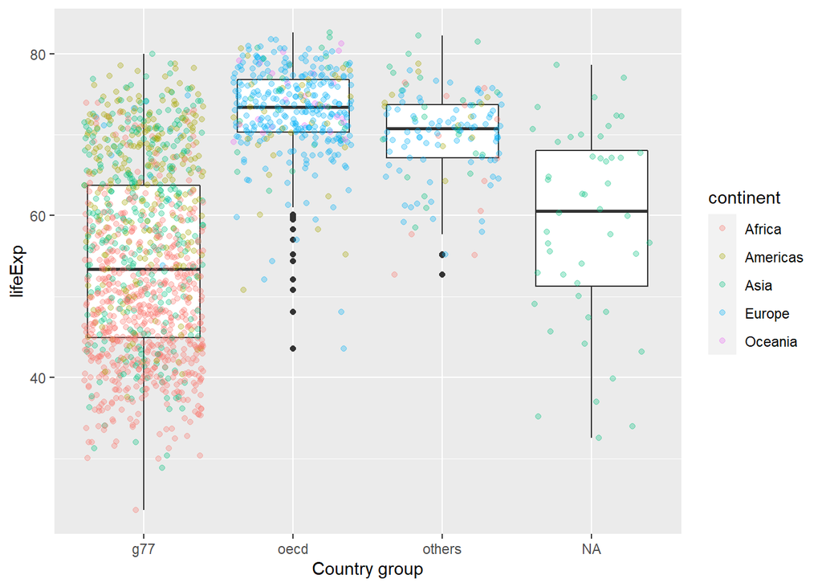

```r
gapminder_extended %>%
  ggplot(aes(x = g77_and_oecd_countries,y = lifeExp)) +
    geom_boxplot() +
    geom_jitter(aes(color = continent), alpha = 0.3) +
    labs(x = "Country group")
```

Compare lifeExp for OECD, G77, and other countries by most common religion

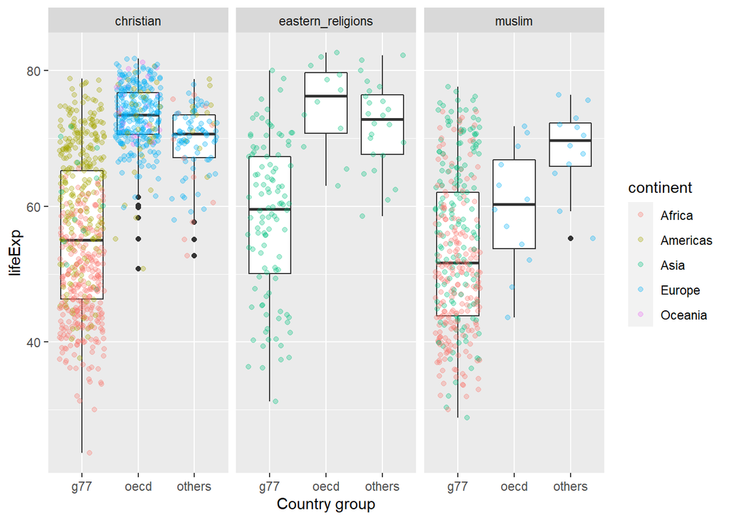

```r
gapminder_extended %>%
  filter(main_religion_2008 %in% c("christian","eastern_religions","muslim")) %>%
  ggplot(aes(x = g77_and_oecd_countries,y = lifeExp)) +
    geom_boxplot() +
    geom_jitter(aes(color = continent), alpha = 0.3) +
    labs(x = "Country group") +
    facet_wrap(~main_religion_2008)
```

## Part 2

Gapminder data is only available from 1952 to 2007. What if we wanted to examine data after 2007 as well as population projections?

Download population size estimates by country from 1800 to 2100

```r
population <- gsheet2tbl("https://docs.google.com/spreadsheets/d/14_suWY8fCPEXV0MH7ZQMZ-KndzMVsSsA5HdR-7WqAC0/edit#gid=176703676")
```

See what population data looks like

```r
glimpse(population)
```

```
## Rows: 59,297
## Columns: 4
## $ geo        <chr> "afg", "afg", "afg", "afg", "afg", "afg", "afg", "afg", "af~
## $ name       <chr> "Afghanistan", "Afghanistan", "Afghanistan", "Afghanistan",~
## $ time       <dbl> 1800, 1801, 1802, 1803, 1804, 1805, 1806, 1807, 1808, 1809,~
## $ Population <dbl> 3280000, 3280000, 3280000, 3280000, 3280000, 3280000, 32800~
```

Only retain population estimates after 2007, rename variables to match gapminder variable names

```r
population <- population %>%
  filter(time > 2007) %>%
  rename(year = time, country = name, pop = Population) %>%
  select(-geo)
```

Add continent data to `population` from `gapminder`

```r
# create a data frame listing continent for every country
continent <- gapminder %>%
  select(country, continent) %>%
  distinct()
# add continent data to population data frame
population <- left_join(population, continent, by = "country")
# see how many countries are missing continent data by continent
population %>%
  group_by(year) %>%
  summarise(missing_continent = sum(is.na(continent)))
```

```
## # A tibble: 93 x 2
##     year missing_continent
##    <dbl>             <int>
##  1  2008                61
##  2  2009                61
##  3  2010                61
##  4  2011                61
##  5  2012                61
##  6  2013                61
##  7  2014                61
##  8  2015                61
##  9  2016                61
## 10  2017                61
## # ... with 83 more rows
```

Use `bind_rows()` to stack `population` below `gapminder`

```r
gapminder_pop <- bind_rows(gapminder, population) %>%
  arrange(country,year)
```

Visualize trends in population growth by continent

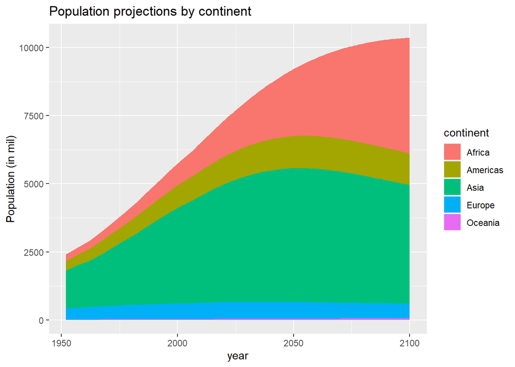

```r
gapminder_pop %>%
  filter(!is.na(continent)) %>%
  group_by(continent, year) %>%
  summarise(pop = sum(pop)/1000000) %>%
  ggplot(aes(x = year, y = pop, fill = continent)) +
  geom_area() +
  labs(title = "Population projections by continent",
               y = "Population (in mil)")
```